# PROPPR Secondary Analysis

Ted Liu

University of Washington - Harborview Medical Center  
tliu2@uw.edu

2021-07-27

# Introduction

## Aims

The aim of this script is to identify underlying groups within the PROPPR dataset.

# Preparation

- Structure of the project folder.
- Libraries used.
- Parameters for the script.

## Structure of Project file

We assume that this script is run from within an RStudio project with the following directory structure:

- PROJECT (root of the RStudio project)
  - documents: where any additional documentation or misc items are stored.
  - data: where data that is imported into the R-environment is stored
  - compare: where the output of the comparison between clustering is stored.
  - R: any R scripts that may need sourcing
  - save: each script has its own subdirectory within save where any progress or output are saved
  - scriptsDraft: working markdown scripts along with corresponding html pdf output
  - scriptsFinal: final markdown scripts

## Libraries

List and describe the libraries that are used by this script

- *tidyverse:* Collection of Tidyverse libraries (https://www.tidyverse.org); The tidyverse is an opinionated collection of R packages designed for data science. All packages share an underlying philosophy and common APIs.
- *openxlsx:* Simplifies the creation of Excel .xlsx files by providing a high level interface to writing, styling and editing worksheets.
- *factoextra:* rovides some easy-to-use functions to extract and visualize the output of multivariate data analyses, including ‘PCA’ (Principal Component Analysis), ‘CA’ (Correspondence Analysis), ‘MCA’ (Multiple Correspondence Analysis), ‘FAMD’ (Factor Analysis of Mixed Data), ‘MFA’ (Multiple Factor Analysis) and ‘HMFA’ (Hierarchical Multiple Factor Analysis) functions from different R packages. It contains also functions for simplifying some clustering analysis steps and provides ‘ggplot2’ - based elegant data visualization.
- *pheatmap:* Implementation of heatmaps that offers more controlover dimensions and appearance.
- *data.table:* Fast aggregation of large data (e.g. 100GB in RAM), fast ordered joins, fast add/modify/delete of columns by group using no copies at all, list columns, friendly and fast character-separated-value read/write. Offers a natural and flexible syntax, for faster development.
- *gridExtra:* Provides a number of user-level functions to work with “grid” graphics, notably to arrange multiple grid-based plots on a page, and draw tables.
- *broom:* The broom package takes the messy output of built-in functions in R, such as lm, nls, or t.test, and turns them into tidy tibbles.

# Pre-Process Data

## Dataset

| biomarker_key_SUBJECTID | log2_Hu_IL_1b__39_std | log2_Hu_IL_1ra__25_std | log2_Hu_IL_4__52_std | log2_Hu_IL_5__33_std |
| --- | --- | --- | --- | --- |
| 1212 | 0.195732212681347 | -0.200857019443686 | 0.397070673653742 | 0.296481266829657 |
| 1438 | -0.770683923906258 | -0.960908424467848 | -1.23583999216324 | -0.0947751657775339 |
| 1648 | 0.51641049304931 | 1.34388582030491 | 0.271482375722156 | 0.916393100685692 |
| 1625 | 0.475254265975609 | 0.660354043332071 | 0.600365968081821 | 0.902064238344989 |
| 1539 | -0.283526175112228 | -0.573494239987172 | -0.18643969158698 | 0.0104136064247186 |
| 1444 | -0.0180549695531703 | 0.391904979145972 | 0.620350052634365 | 0.55549524930941 |

## Description

This data set is from the Pragmatic, Randomized Optimal Platelet and Plasma Ratios trial, which compared 1:1:1 to 1:1:2 plasma:platelets:RBC transfusion strategies. This was a multicenter trial that enrolled from 12 North American Level 1 trauma centers.

| INJ_MECH | female1 | n |
| --- | --- | --- |
| Blunt Injury Only | 0 | 178 |
| Blunt Injury Only | 1 | 72 |
| Penetrating Injury Only | 0 | 201 |
| Penetrating Injury Only | 1 | 20 |

| female1 | Mean_Age |
| --- | --- |
| 0 | 37.64908 |
| 1 | 43.63043 |

| INJ_MECH | Death | n |
| --- | --- | --- |
| Blunt Injury Only | 0 | 173 |
| Blunt Injury Only | 1 | 77 |
| Penetrating Injury Only | 0 | 187 |
| Penetrating Injury Only | 1 | 34 |

# Hierarchical Clustering

## Silhouette Analysis

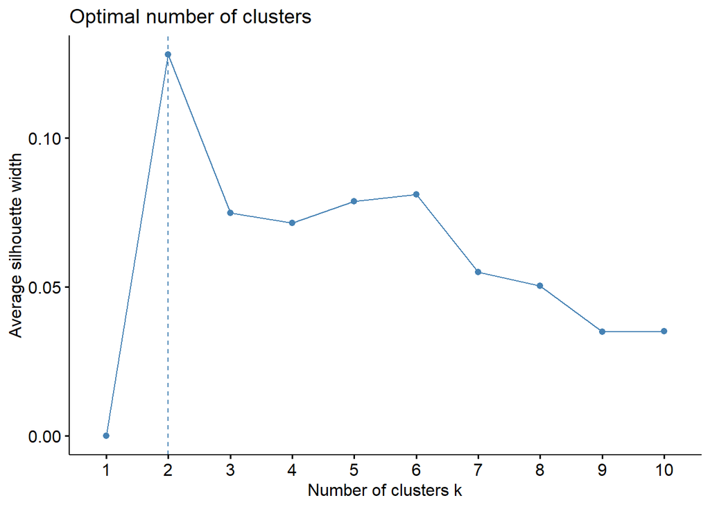

## Heatmap

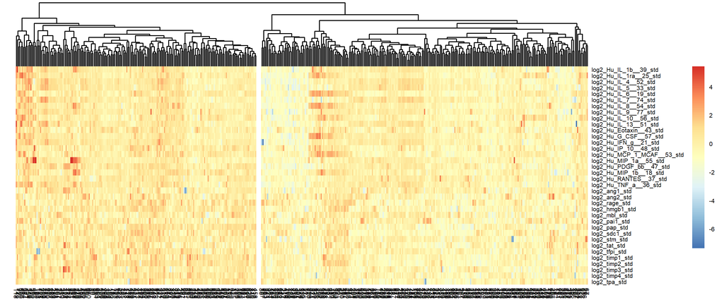

Hierarchical Clustering Heatmap

## PCs and Var Contrib

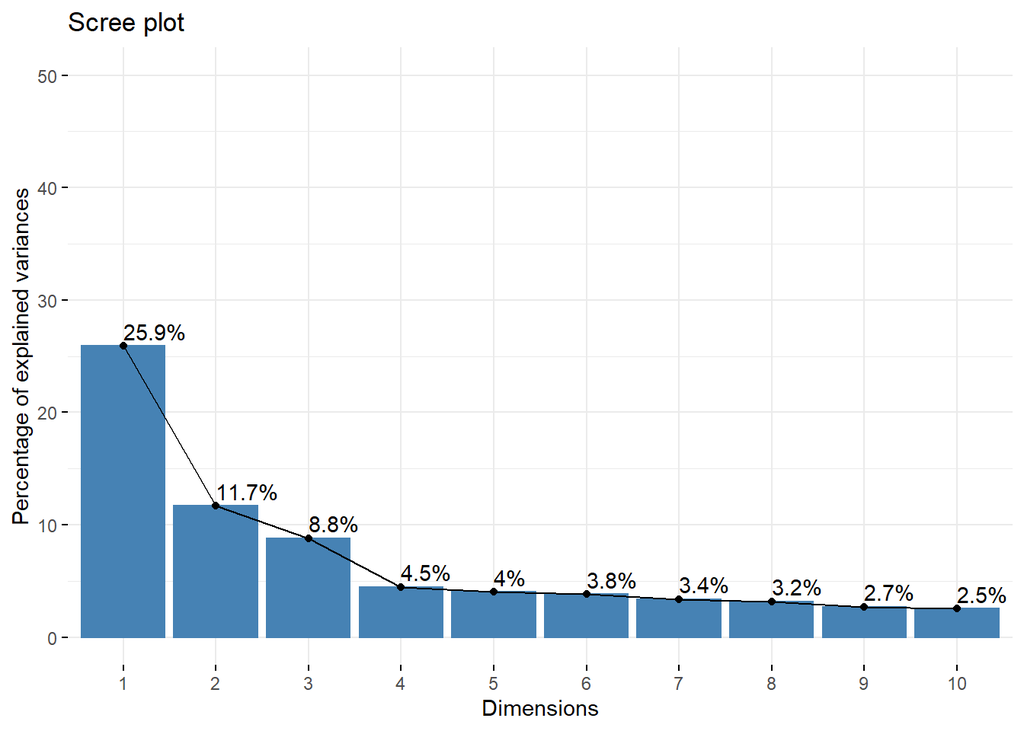

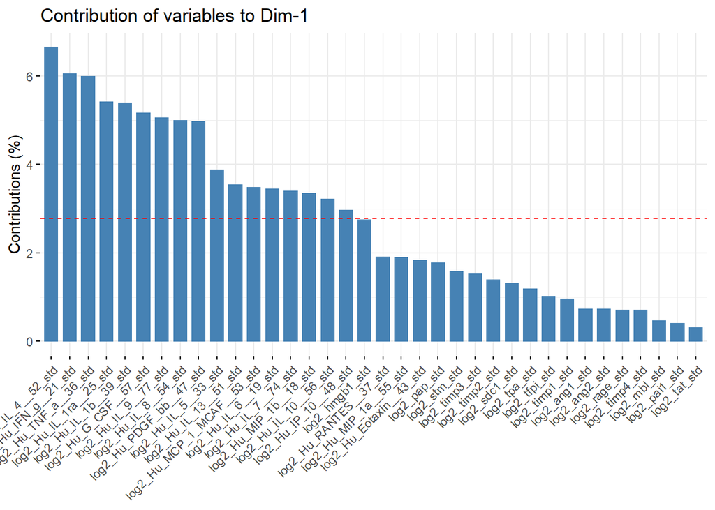

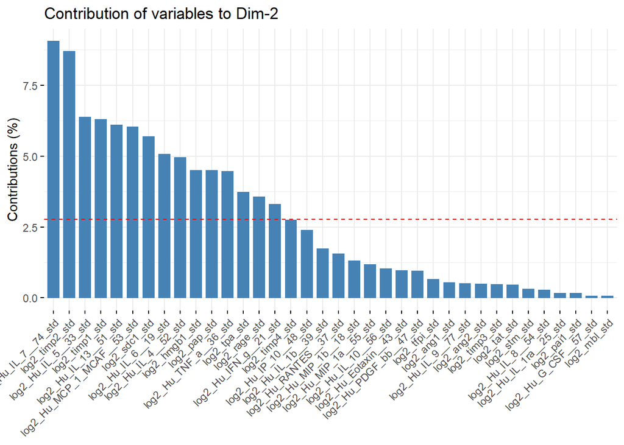

## PCA Plot

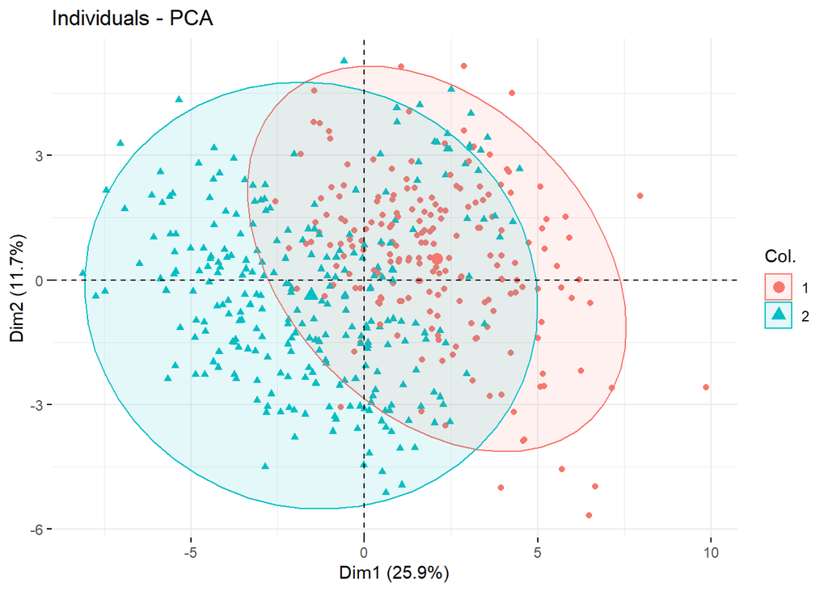

## Outcomes

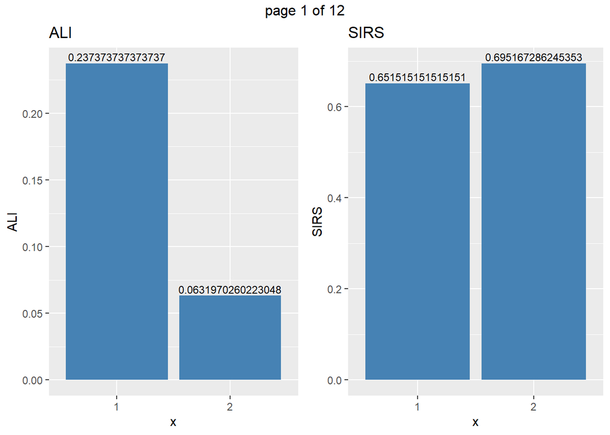

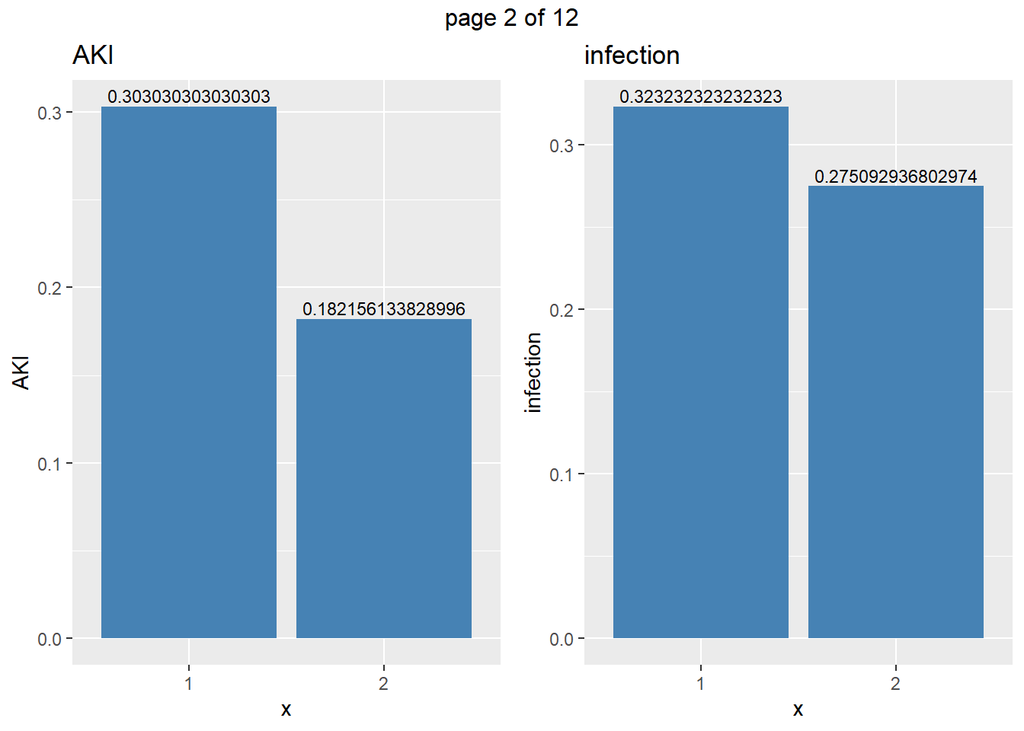

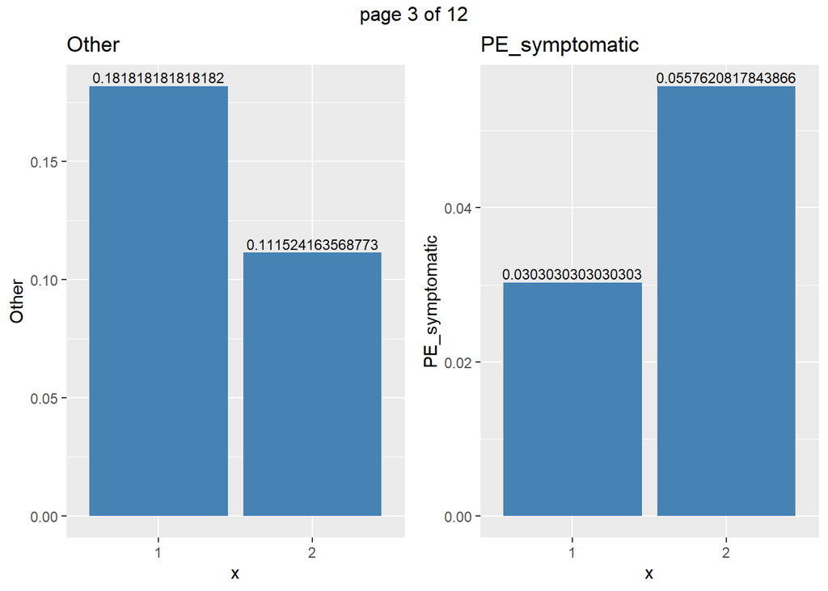

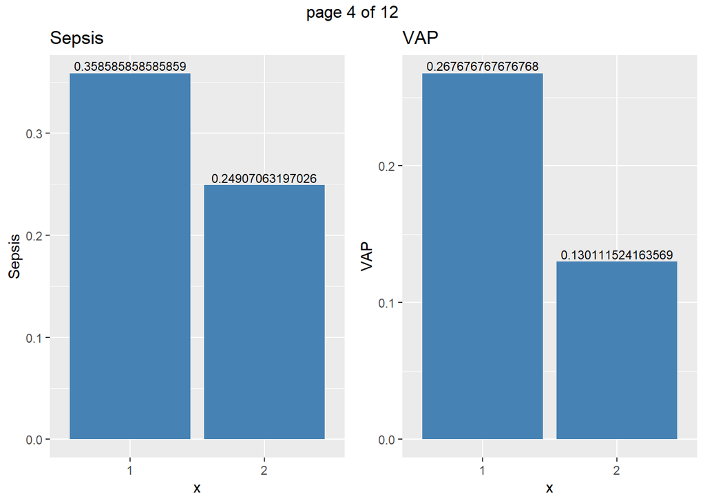

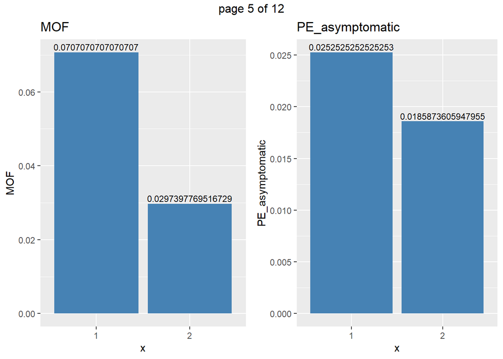

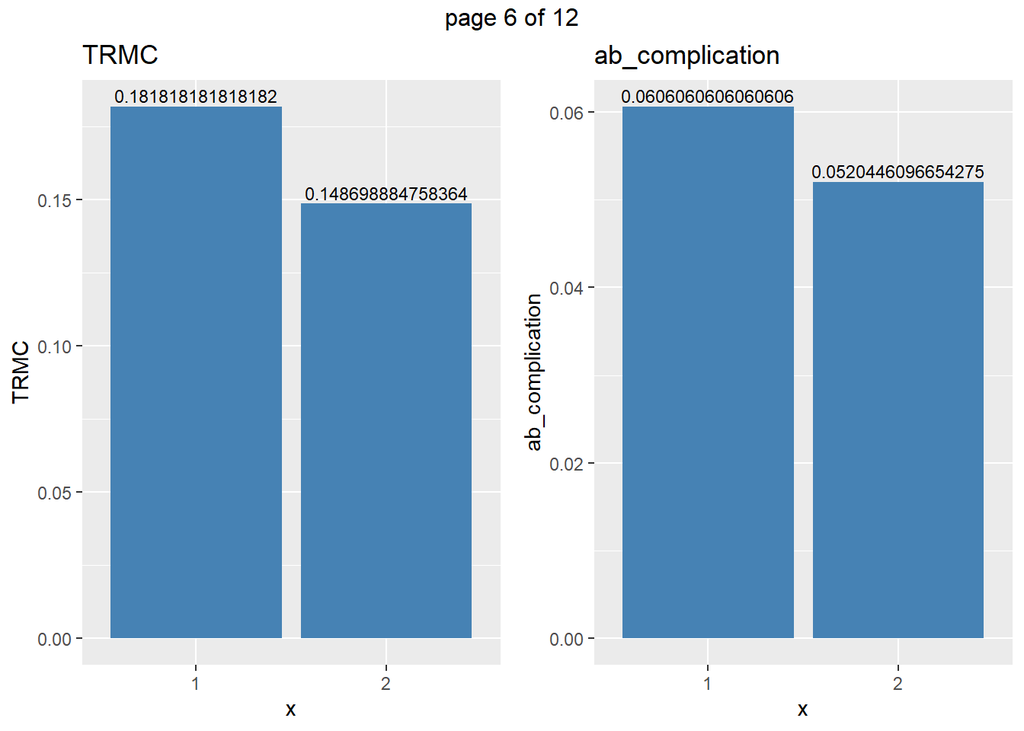

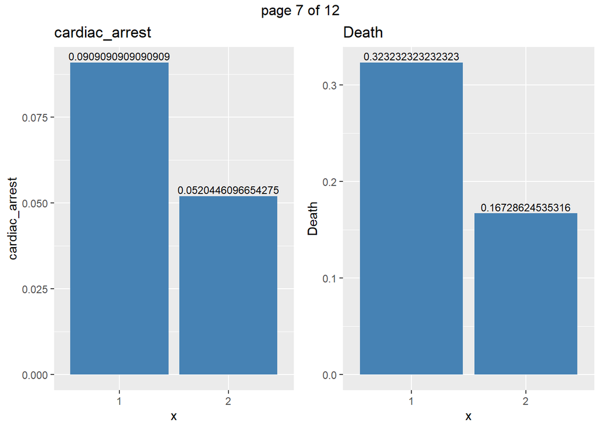

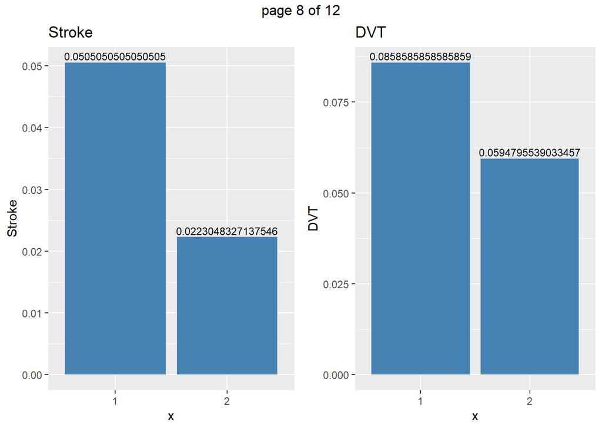

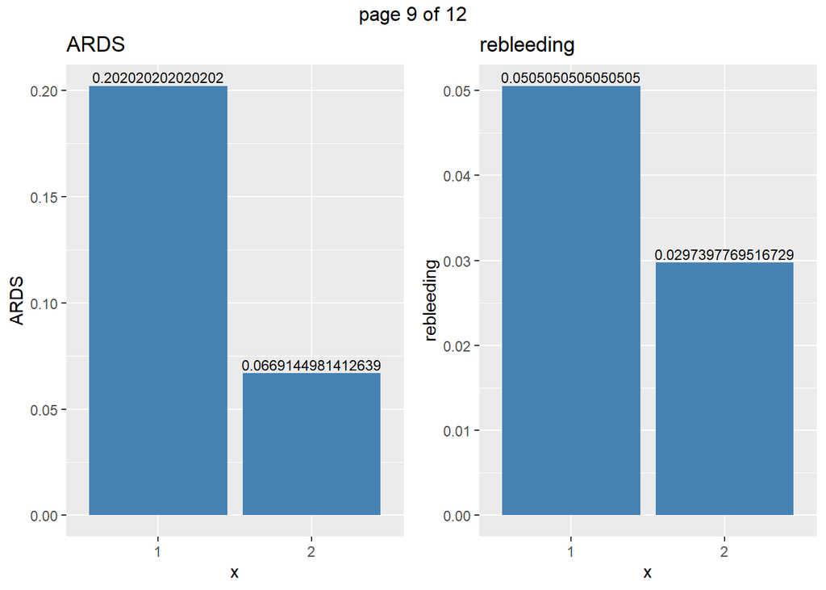

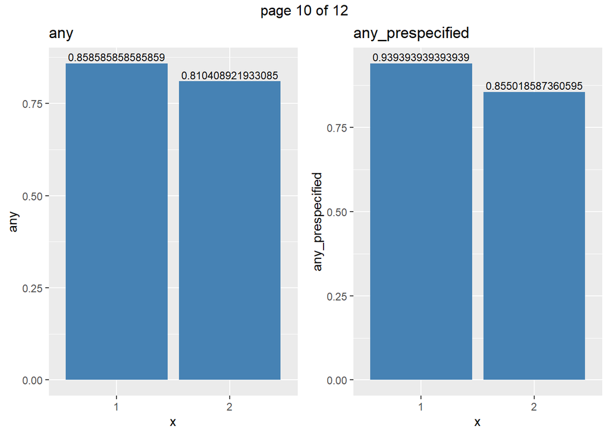

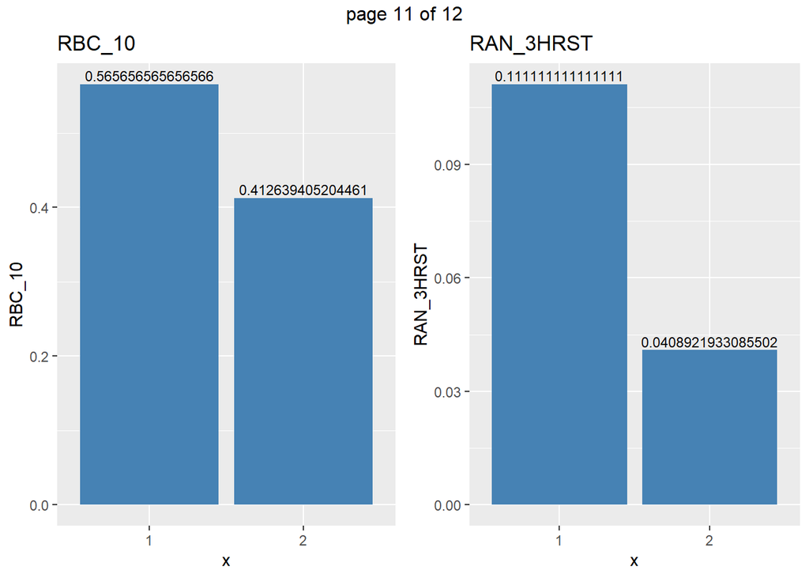

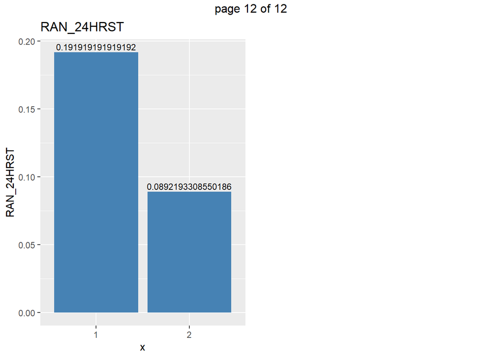

# K-Means Clustering

## Silhouette Analysis

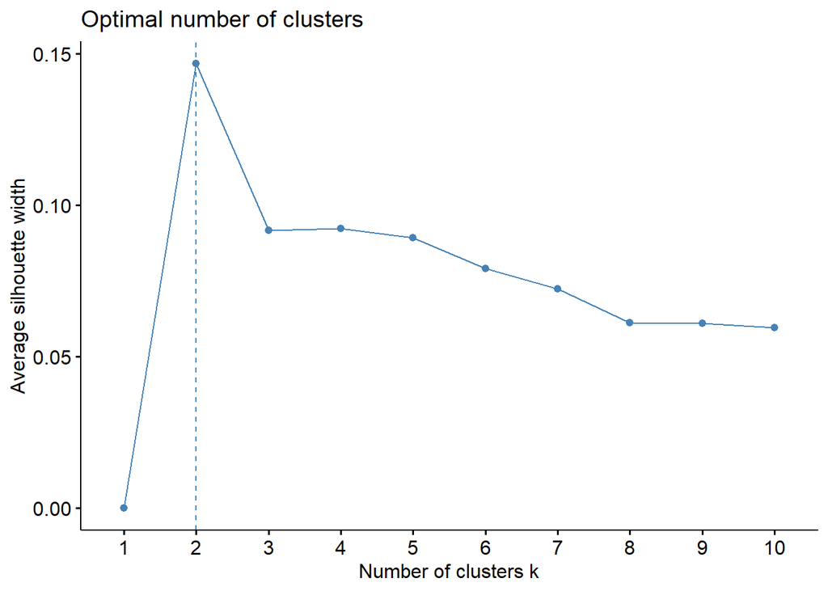

## Heatmap

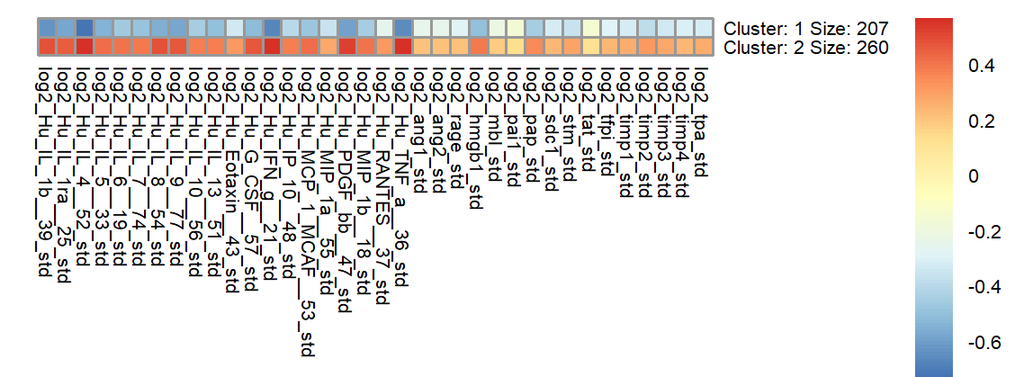

## PCs and Var Contrib

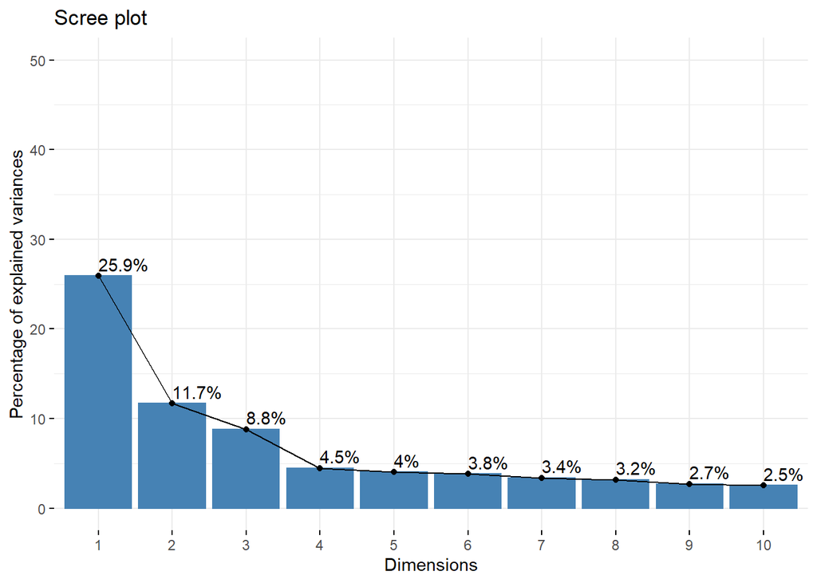

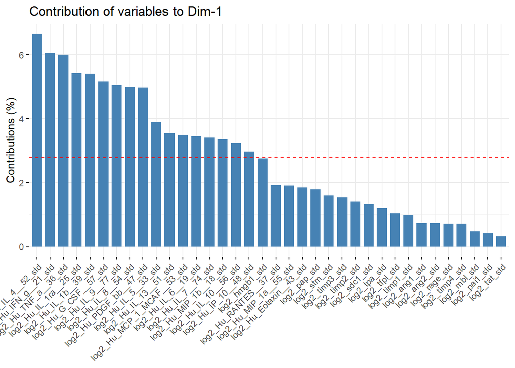

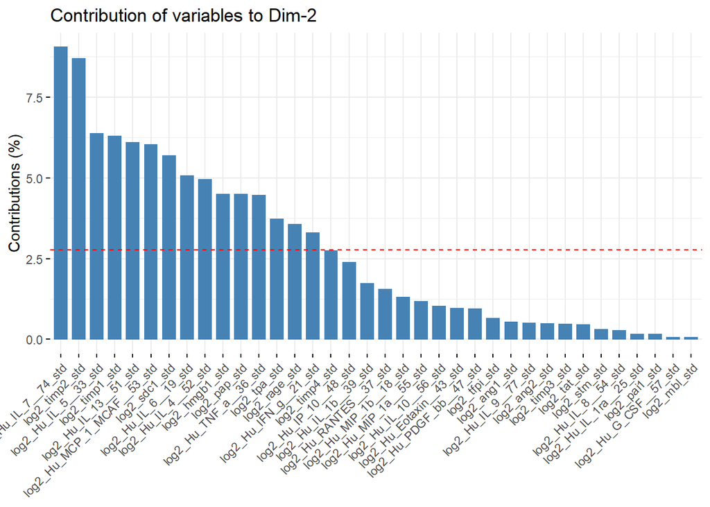

## Outcomes

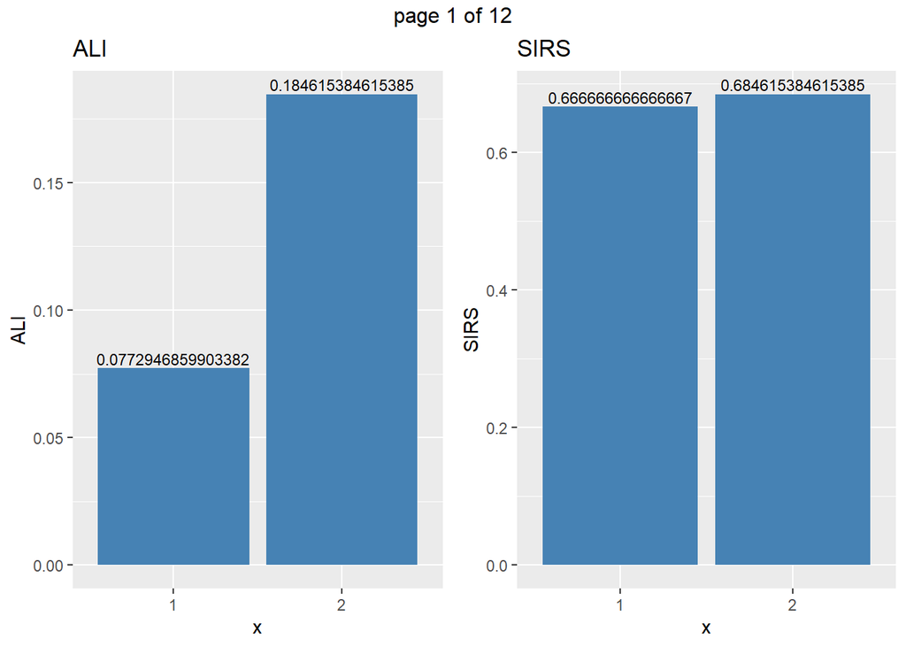

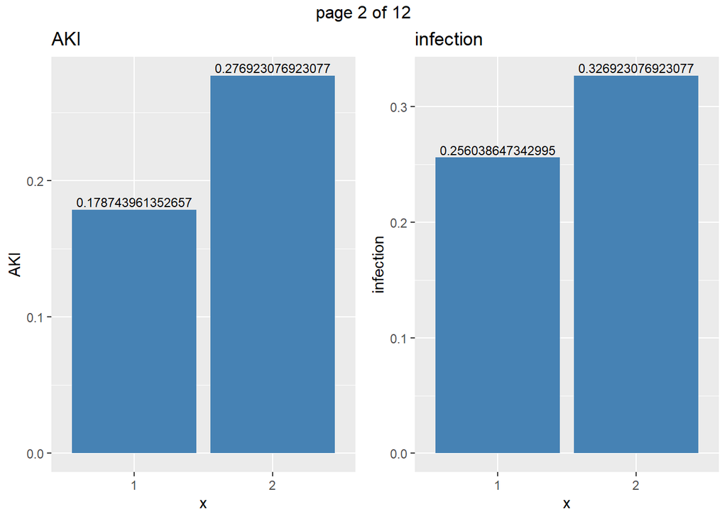

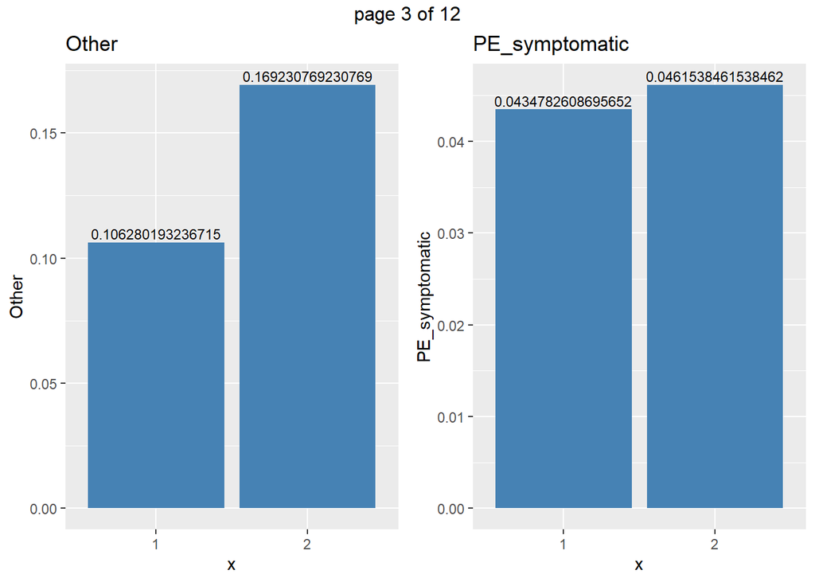

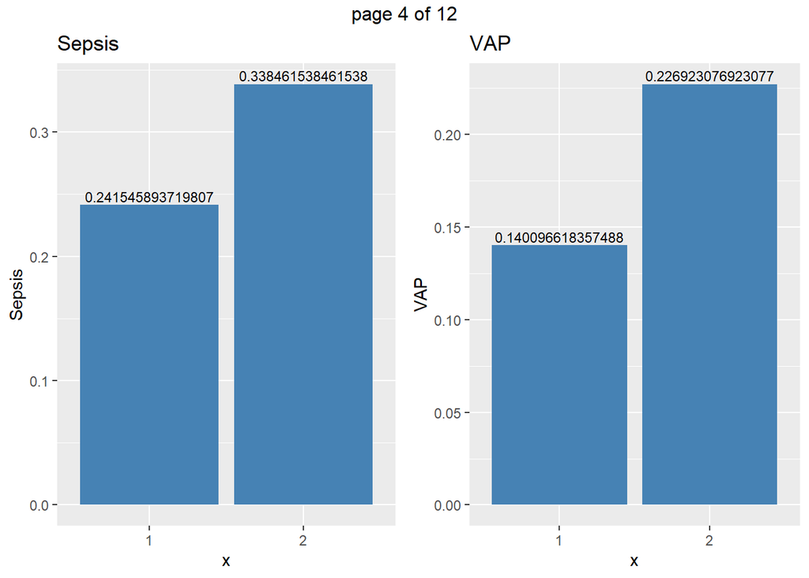

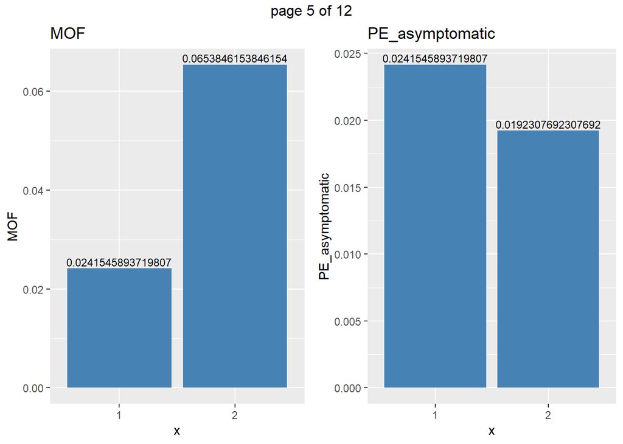

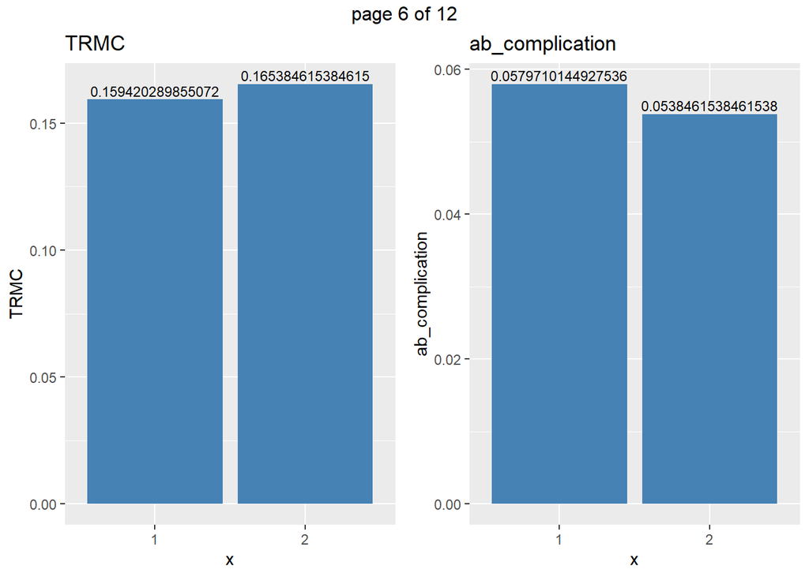

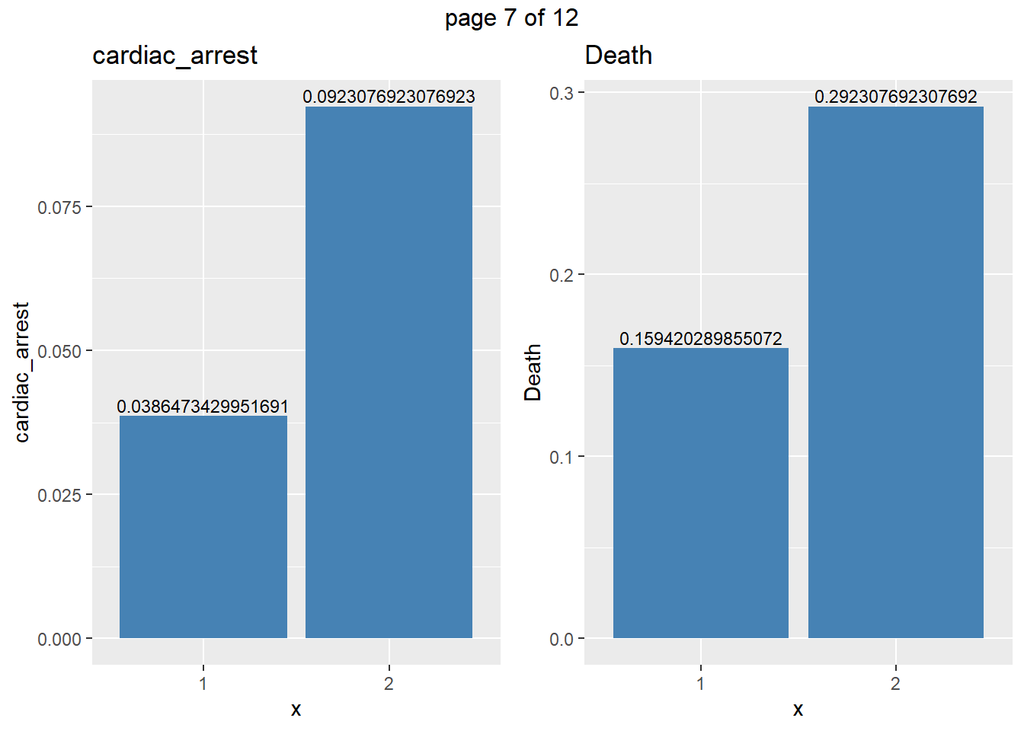

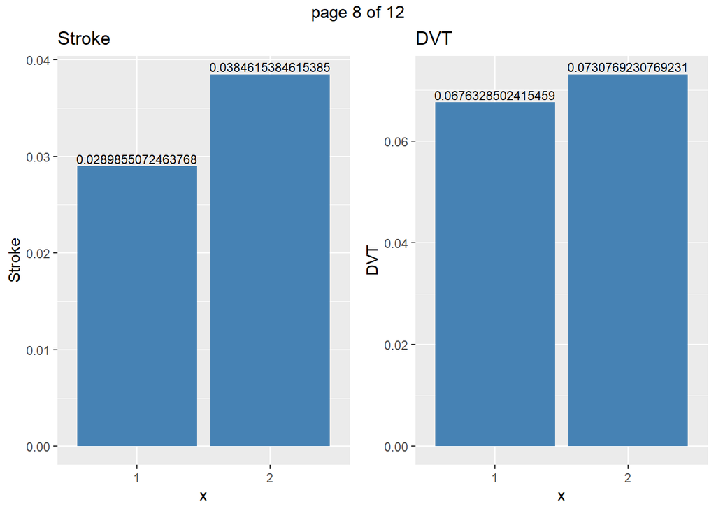